# IODS course project

### Visualizing clusters and interpreting results

We can observe that the crime rates and the proproty tax values are clustered very separatelly, wich suggests that in poorer neighbourhood there is more crime.

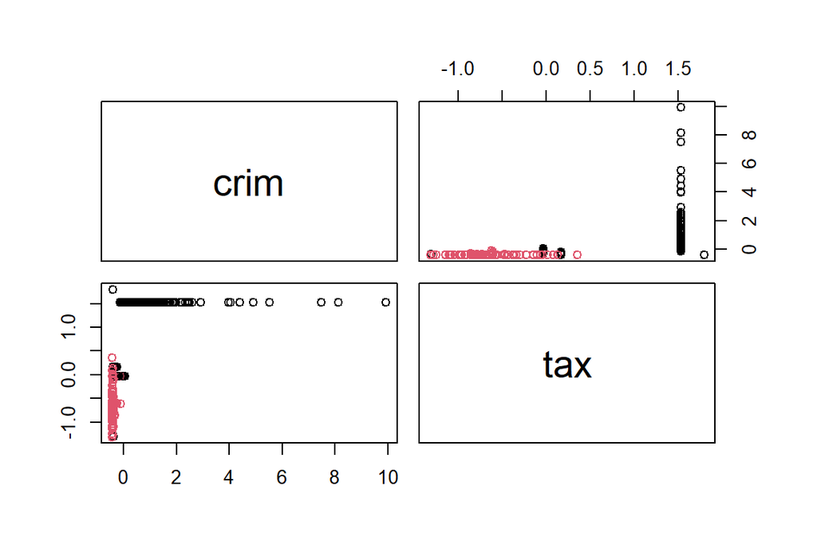

```r
pairs(Boston_scaled[c(1,10)], col = km$cluster)
```

Also, it seems that ihousing value and age show a large cluster in black, with old houses and low value.

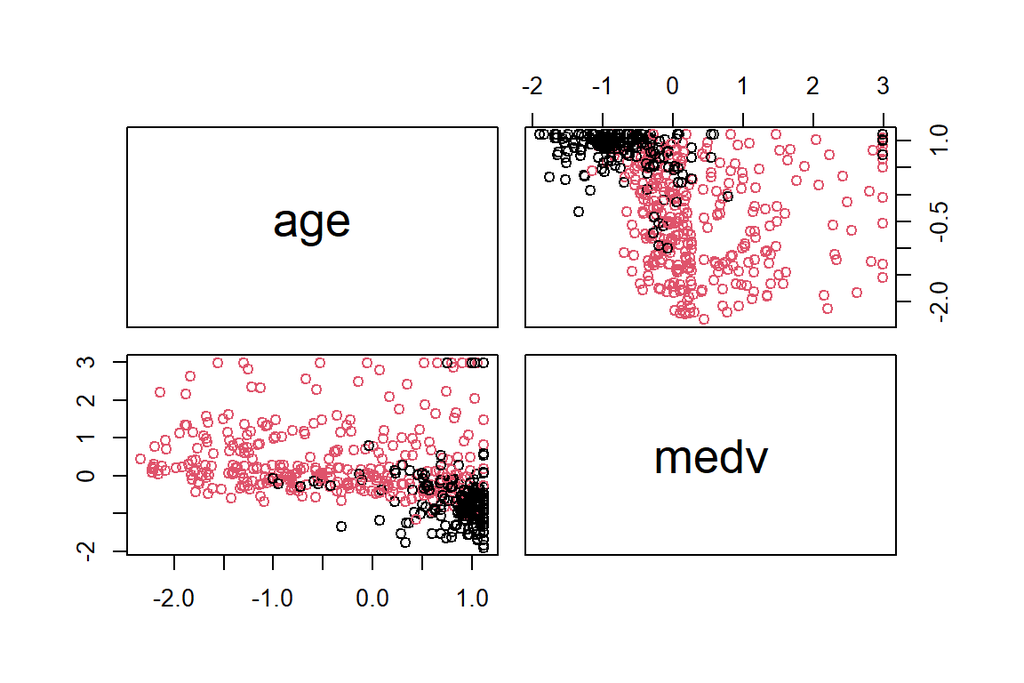

```r
pairs(Boston_scaled[c(7,14)], col = km$cluster)
```

## 5 | Bonus task

```r
data("Boston")

Boston_scaled<-as.data.frame(scale(Boston))


km <- kmeans(Boston_scaled, centers = "5")
```

Then, fit LDA with clusters as the target (dependent)

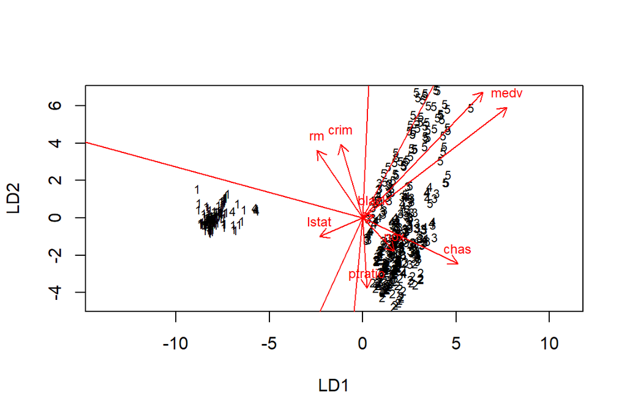

```r
lda.fit <- lda(km$cluster ~ . , data = Boston_scaled)

lda.arrows <- function(x, myscale = 1, arrow_heads = 0.1, color = "red", tex = 0.75, choices = c(1,2)){
  heads <- coef(x)
  graphics::arrows(x0 = 0, y0 = 0,
         x1 = myscale * heads[,choices[1]],
         y1 = myscale * heads[,choices[2]], col=color, length = arrow_heads)
  text(myscale * heads[,choices], labels = row.names(heads),
       cex = tex, col=color, pos=3)
}

# target classes as numeric
classes <- as.numeric(km$cluster)

# plot the lda results (select both lines and execute them at the same time!)
plot(lda.fit, dimen = 2)
lda.arrows(lda.fit, myscale =22)
```

# Dimensionality reduction techniques

In this chapter, we will learn about dimensionality reduction techniques, and more particularly about the Principal Component Analysis (PCA). PCA is a popular technique for analyzing large datasets containing a high number of dimensions/features per observation, increasing the interpretability of data while preserving the maximum amount of information, and enabling the visualization of multidimensional data.

In addition, we will learn about the Correspondence Analysis, which can be used when we have categorical variables.

## 1 | Data Overview

### Intorduction

For this chapter, we will use the data from the UN Development Programme that we wrangled previously. However, it is also avaliable in the following link: https://hdr.undp.org/system/files/documents/technical-notes-calculating-human-development-indices.pdf

The dataset contains variables related to Human Development Index and Gender Inquality. More specifically, the data set contains the following variables:

```r
library(tibble)
library(readr)

human <- read_csv("https://raw.githubusercontent.com/KimmoVehkalahti/Helsinki-Open-Data-Science/master/datasets/human2.csv")
human <- column_to_rownames(human, "Country")
summary(human)
```

```
##     Edu2.FM          Labo.FM          Life.Exp        Edu.Exp
##  Min.   :0.1717   Min.   :0.1857   Min.   :49.00   Min.   : 5.40
##  1st Qu.:0.7264   1st Qu.:0.5984   1st Qu.:66.30   1st Qu.:11.25
##  Median :0.9375   Median :0.7535   Median :74.20   Median :13.50
##  Mean   :0.8529   Mean   :0.7074   Mean   :71.65   Mean   :13.18
##  3rd Qu.:0.9968   3rd Qu.:0.8535   3rd Qu.:77.25   3rd Qu.:15.20
##  Max.   :1.4967   Max.   :1.0380   Max.   :83.50   Max.   :20.20
##       GNI            Mat.Mor         Ado.Birth         Parli.F
##  Min.   :   581   Min.   :   1.0   Min.   :  0.60   Min.   : 0.00
##  1st Qu.:  4198   1st Qu.:  11.5   1st Qu.: 12.65   1st Qu.:12.40
##  Median : 12040   Median :  49.0   Median : 33.60   Median :19.30
##  Mean   : 17628   Mean   : 149.1   Mean   : 47.16   Mean   :20.91
##  3rd Qu.: 24512   3rd Qu.: 190.0   3rd Qu.: 71.95   3rd Qu.:27.95
##  Max.   :123124   Max.   :1100.0   Max.   :204.80   Max.   :57.50
```

```r
str(human)
```

```
## 'data.frame':    155 obs. of  8 variables:
##  $ Edu2.FM  : num  1.007 0.997 0.983 0.989 0.969 ...
##  $ Labo.FM  : num  0.891 0.819 0.825 0.884 0.829 ...
##  $ Life.Exp : num  81.6 82.4 83 80.2 81.6 80.9 80.9 79.1 82 81.8 ...
##  $ Edu.Exp  : num  17.5 20.2 15.8 18.7 17.9 16.5 18.6 16.5 15.9 19.2 ...
##  $ GNI      : num  64992 42261 56431 44025 45435 ...
##  $ Mat.Mor  : num  4 6 6 5 6 7 9 28 11 8 ...
##  $ Ado.Birth: num  7.8 12.1 1.9 5.1 6.2 3.8 8.2 31 14.5 25.3 ...
##  $ Parli.F  : num  39.6 30.5 28.5 38 36.9 36.9 19.9 19.4 28.2 31.4 ...
```

### Graphical overview

And now let’s visualize how is the data, and we will show summaries of them. We will also look at how the variables are related between each other.

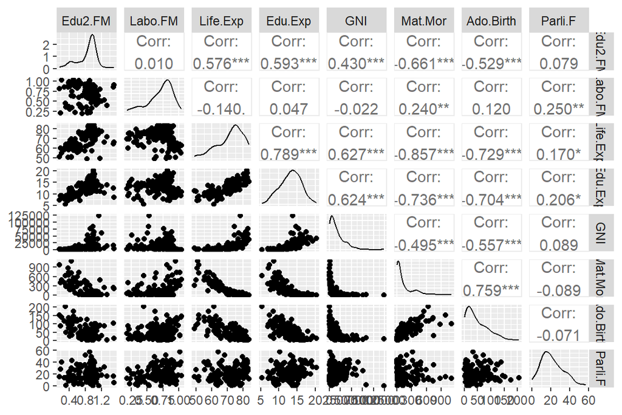

```r
library(GGally)
ggpairs(human, progress = FALSE)
```

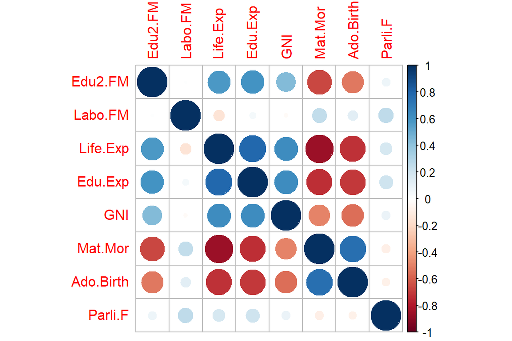

```r
library(corrplot)
cor(human) %>% corrplot()
```

The two plots provide distinct visualizations of the same correlation information. In the latter plot, correlation strength is represented by circle size, with colors indicating the correlation sign (deep red for negative, deep blue for positive). The distribution of some variables takes on a relatively normal appearance, while others display skewed patterns with extended tails.

Examining the gender-specific labor market participation ratio reveals a lack of notable correlations with other variables. In contrast, maternal mortality shows a strong negative correlation with life expectancy and female education ratio, coupled with a positive correlation with adolescent birth rate—patterns evident in the scatterplots of the initial graph. Significant correlations are also apparent with variables like life expectancy and length of education.

## 2 | Principal Component Analysis

Now, we will perform the PCA as follows:

```r
library(tibble)
pca_human <- prcomp(human)
# create and print out a summary of pca_human
s <- summary(pca_human)

# rounded percentanges of variance captured by each PC
pca_pr <- round(1*s$importance[2, ], digits = 5) * 100

# print out the percentages of variance
pc_lab <- print(pca_pr)
```

```
##   PC1   PC2   PC3   PC4   PC5   PC6   PC7   PC8
## 99.99  0.01  0.00  0.00  0.00  0.00  0.00  0.00
```

```r
# create object pc_lab to be used as axis labels
paste0(names(pca_pr), " (", pca_pr, "%)")
```

```
## [1] "PC1 (99.99%)" "PC2 (0.01%)"  "PC3 (0%)"     "PC4 (0%)"     "PC5 (0%)"
## [6] "PC6 (0%)"     "PC7 (0%)"     "PC8 (0%)"
```

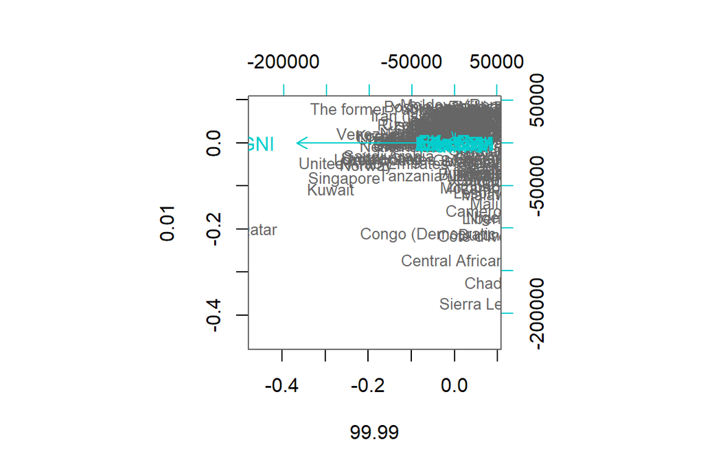

```r
biplot(pca_human,
       cex = c(0.8, 1),
       col = c("grey40", "cyan3"),
       xlab = pc_lab[1],
       ylab = pc_lab[2])
```

In the unscaled scenario, the initial component accounts for an impressive 99% of the variance; however, the associated biplot doesn’t appear to provide meaningful insights. This dominance can be attributed to GNI, as it singularly captures the entire spectrum with significantly higher values compared to other components

## 3 | Standarized Principal Component Analysis

Now, we will standarize the variables in the dataset and repeat the analysis. We will se if the results are different.

```r
#standarize the dataset
human_std <- scale(human)
pca_human_scaled <- prcomp(human_std)

# create and print out a summary of pca_human
s_scaled <- summary(pca_human_scaled)

# rounded percentanges of variance captured by each PC
pca_pr_scaled <- round(1*s_scaled$importance[2, ], digits = 5) * 100

# print out the percentages of variance
pc_lab_scaled <- print(pca_pr_scaled)
```

```
##    PC1    PC2    PC3    PC4    PC5    PC6    PC7    PC8
## 53.605 16.237  9.571  7.583  5.477  3.595  2.634  1.298
```

Now let’s plot it

```r
# create object pc_lab to be used as axis labels
paste0(names(pca_pr_scaled), " (", pca_pr_scaled, "%)")
```

```
## [1] "PC1 (53.605%)" "PC2 (16.237%)" "PC3 (9.571%)"  "PC4 (7.583%)"
## [5] "PC5 (5.477%)"  "PC6 (3.595%)"  "PC7 (2.634%)"  "PC8 (1.298%)"
```

[figure not shown]

```r
biplot(pca_human_scaled,
       cex = c(0.8, 1),
       col = c("grey40", "cyan3"),
       xlab = pc_lab[1],
       ylab = pc_lab[2])
```

From this result, we can see that scaling the data is crucial because it encompasses variables with diverse distributions. The visualization, marked by blue arrows, delineates the correlation direction and strength linked to the components.

Upon scaling, the first two components jointly account for about 70% of the variation. Notably, the second component appears to index female parliamentary participation percentage and labor market participation ratio, leaving the first component to encapsulate the remaining variables, impacting them positively or negatively.